### Missing data

Hide $\{25\%, 50\%, 75\%\}$ of the data in $\{1, 2, 3\}$ of the views. That is,

- based on the values in the latent space, generate data for 4 gaussian views, each with 50 features, and the binary outcome y
- choose randomly $\{25\%, 50\%, 75\%\}$ of individuals and set their values in all of the $\{1, 2, 3\}$ views to NA

Compare **multi-view imputation** method with two baselines:

- **multi-view available cases** - for each missingness pattern in test data (e.g. for the first view missing (Mis, Obs, Obs, Obs)) we train the multi-view method on all training data that has (at least) these three views available
- **logistic regression per view** - train an ordinary logistic regression model (without regularisation) on each view separately. To obtain predictions, we average the log odds on the logit scale from all available views.

### Equal amount of missingness in train and test data

Scenario: $X \%$ missingness in both train and test data

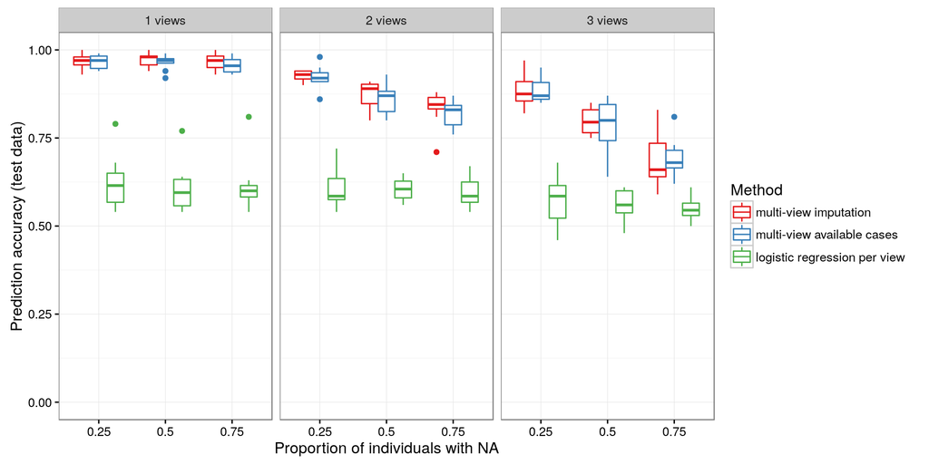

Conclusion: Difficult to say whether imputation improves predictions.

### Missingness only in training data

Scenario: $X \%$ missingness in training data only (test data is fully observed)

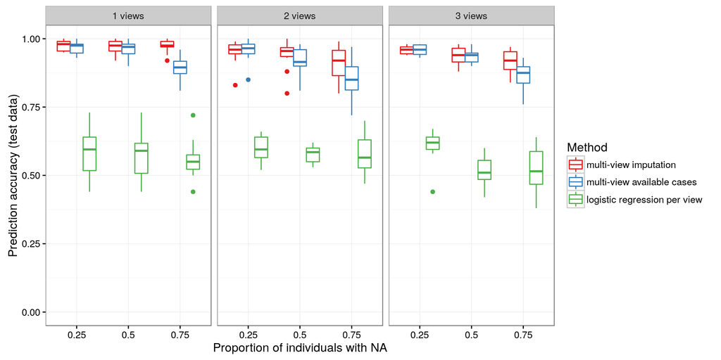

Conclusion: In this scenario, indeed imputation seems to improve predictions.

### Missingness only in test data

Scenario: $X \%$ missingness in test data only (training data is fully observed)

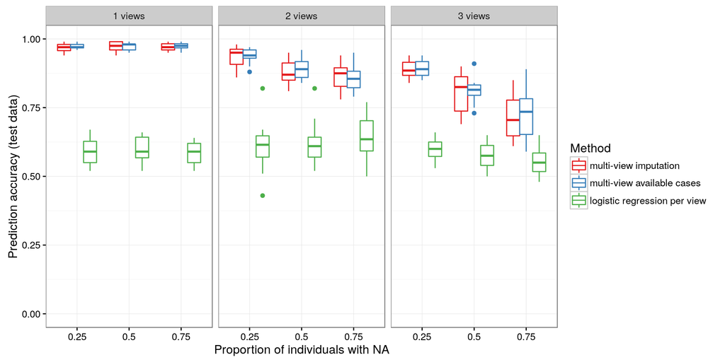

Conclusion: Imputation does not seem to help.

### Imputation accuracy

So far we explored prediction accuracy. Now we also evaluated multi-view imputation accuracy on training data, using mean absolute error. As a baseline, we used feature-wise median imputation.

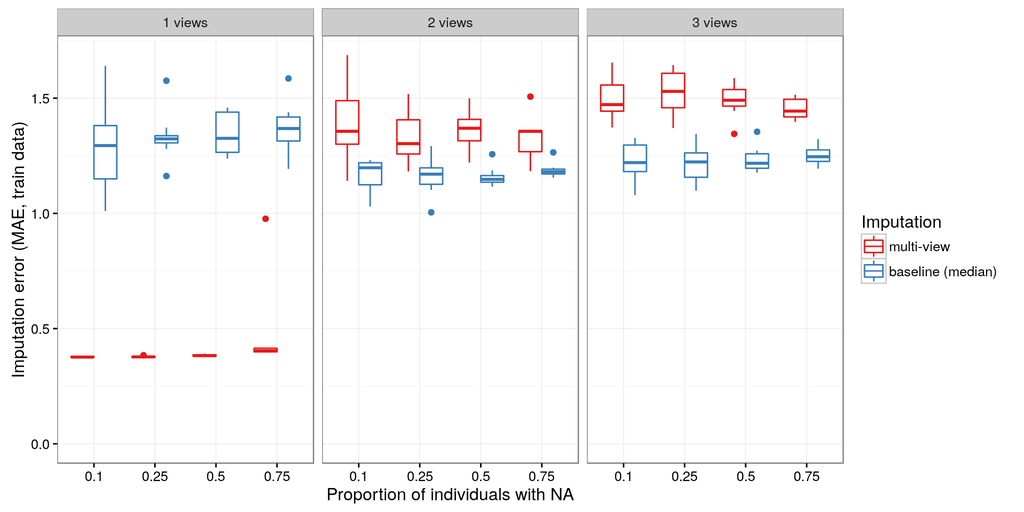

Conclusion: In this scenario (when there was a relatively strong dependence between views 1 and 2), missingness only in one view could be handled relatively well (regardless of the amount of missingness in that view), but even when a small portion of 2 views were simultaneously missing, the imputation accuracy was worse than the baseline.